# Stan notebook: a prototype

NGS2 Kickoff Meeting. October 27, 2016

## Reproducing other people's data analysis is HARD.

[figure not shown]

## Stan notebook

- Transparent modeling
- Reproducible computing
- Efficient Bayesian inference
- Enabled simulation-based model checking

## Simulation - hierarchical Bayesian regression model

**Demo**: This is an R Markdown presentation with `RStan` modeling, adapted from an `ipynb` R notebook using Stan created by Milad Kharratzadeh.

http://bit.ly/StanNbDemo1

## A meta-analysis of experimental studies of an education intervention

Consider a model with

- varying slopes
- varying intercepts
- individual-level predictors
- group-level predictors.

Meta-analysis of experimental studies of an education intervention (e.g., a new coaching program).

## Simulation setup

- A total of \(n\) students
- In \(J\) different schools
- For each student
  - \(y_i\), a measure of improvment;
  - \(P\) predictors, \({\bf x}_i\), (1 for intercept, socio-economic status, number of study hours, pre-treatment test score, parent's education level, etc.)

## Data generating model

- A within-group model of how the individual-level predictors affect the measure of improvement: \[y_i = {\bf x}_n^T\boldsymbol{\beta}_{g[i]}+\varepsilon_i,\ \varepsilon_i \sim \text{N} (0, \sigma^2), \qquad i=1, \ldots, n,\] where \(g[i]\in \{1, \ldots, J\}\) is the group (i.e., school) of the \(i\)th student.
- A multi-variate Normal distribution for the varying coefficients: \[\boldsymbol{\beta}_j={\bf u}_j^T \boldsymbol{\gamma}+\boldsymbol{\eta}_j, \ , \boldsymbol{\eta}_j\sim\text{MVN}({\bf 0}, \boldsymbol{\Sigma}), \qquad j=1, \ldots, J,\] where \({\bf u}_j\) are the school-level predictors (e.g., size of classrooms or historical performance) , and \(\boldsymbol{\gamma}\) is the group-level coefficient matrix.

## Hyper priors

- A weakly informative prior, \(\text{N}(0,5)\), on the elements of \(\boldsymbol{\gamma}\).
- The covariance matrix is decomposed into a scale and a correlation matrix as follows: \[\boldsymbol{\Sigma} = \text{diag}(\boldsymbol{\tau}) \ \boldsymbol{\Omega} \ \text{diag}(\boldsymbol{\tau}), \] where \({ \bf \tau}\) are scale coefficients and \({ \bf \Omega}\) is the correlation matrix.
  - \({\bf \tau}_i \sim \text{Cauchy} (0, 2.5),\ { \bf \tau}_i>0,\ \text{weakly informative prior,}\)
  - \(\boldsymbol{\Omega} \sim \text{LKJcorr}(2),\)
  - The LKJ prior is for parameter \(\nu\) is proportional to \(|\text{det}({\bf \Omega})|^{\nu-1}\).

## Generating Simulated Data

Specify stan codes for generating data: `generatedata.stan`.

```r
file_path <- "generateData.stan"
lines <- readLines(file_path, encoding="ASCII")
for (n in 1:length(lines)) cat(lines[n],'\n')
```

```
data {
  int<lower=1> J;                     // Number of groups
  int<lower=1> Q;                     // Number of group-level predictors
  int<lower=1> N;                     // Number of individuals
  int<lower=1> P;                     // Number of individual-level predictors
  int<lower=1, upper=J> gg[N];        // Grouping
}
```

## Generating Simulated Data

```
parameters {
}

model {
}
```

## Generating Simulated Data

```
generated quantities {
  matrix<lower=0, upper=2>[N, P] X;   // Individual predictors
  matrix<lower=0, upper=5>[J, Q] U;   // Group predictors
  real<lower=0> sigma;                // Observation error
  matrix[Q, P] gamma;                 // Group-level coefficients
  matrix[P, J] Z;                     // Z will be used later to build Beta
  vector<lower=0>[P] tau;             // Prior scale
  cholesky_factor_corr[P] Omega_chol; // Cholesky decomposition of Omega
  matrix[J, P] Beta;                  // Individual-level coefficients
  vector[N] Y;                        // Responses
```

## Generating Simulated Data

```
  sigma = 10;
  for (p in 1:P) {
    tau[p] = fabs(cauchy_rng(0,2.5));
    for (j in 1:J)
      Z[p,j] = normal_rng(0, 1);
    for (n in 1:N)
      X[n,p] = uniform_rng(0,2);
    for (q in 1:Q)
      gamma[q,p] = normal_rng(0, 5);
  }
```

## Generating Simulated Data

```
  for (j in 1:J) {
    for (q in 2:Q)
      U[j,q] = uniform_rng(0,5);
  }

  X[:,1] = rep_vector(1,N); // Intercept
  U[:,1] = rep_vector(1,J); // Intercept
  Omega_chol = lkj_corr_cholesky_rng(P, 2);
  Beta = U * gamma + (diag_pre_multiply(tau, Omega_chol) * Z)';

  for (n in 1:N)
    Y[n] = normal_rng(dot_product(Beta[gg[n]] , X[n]),sigma);
}
```

## Generating Simulated Data

```
##
##
## Chain 1, Iteration: 1 / 1 [100%]  (Sampling)
##  Elapsed Time: 5e-06 seconds (Warm-up)
##                0.000594 seconds (Sampling)
##                0.000599 seconds (Total)
```

## Generated data

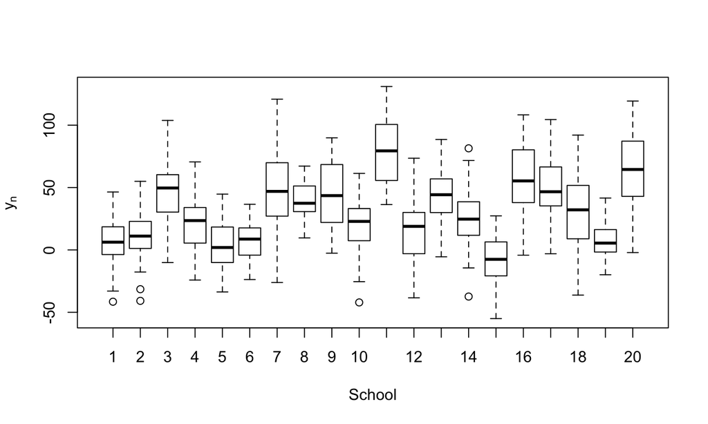

## Generated data

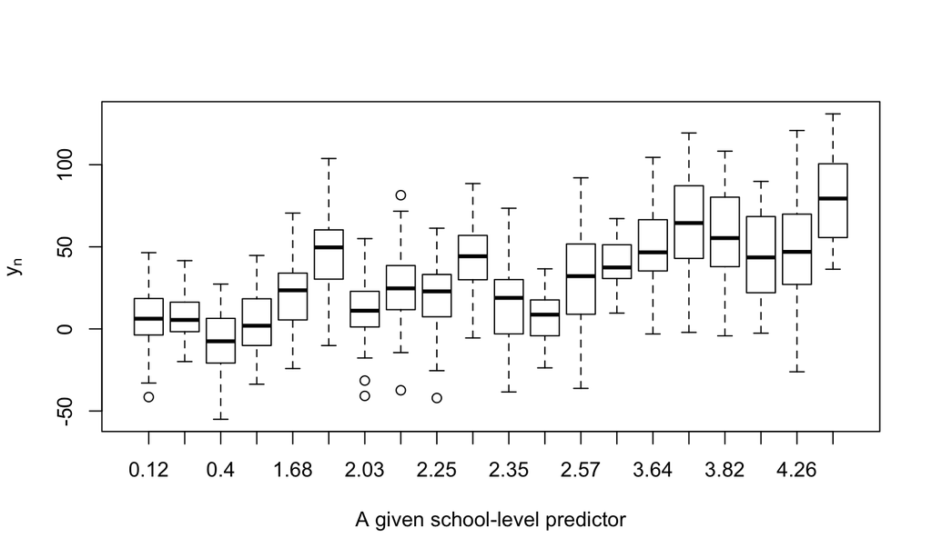

## Fitting the model

Set up `HierarchicalRegression.stan`.

```r
file_path <- "HierarchicalRegression.stan"
lines <- readLines(file_path, encoding="ASCII")
for (n in 1:length(lines)) cat(lines[n],'\n')
```

## Fitting the model

```
data {
  int<lower=1> J; // Number of groups
  int<lower=1> Q; // Number of group-level predictors
  int<lower=1> N; // Number of individuals
  int<lower=1> P; // Number of individual-level predictors
  int<lower=1, upper=J> gg[N]; // Grouping
  matrix[N, P] X; // Individual predictors
  matrix[J, Q] U; // Group predictors
  vector[N] Y;    // Responses
}
```

## Fitting the model

```
parameters {
  real<lower=0> sigma;    // Observation error
  matrix[Q, P] gamma;     // Group-level coefficients
  matrix[P, J] Z;         // Z will be used later to build Beta
  vector<lower=0>[P] tau; // Prior scale
  cholesky_factor_corr[P] Omega_chol; // Cholesky decomposition of Omega
}
```

## Fitting the model

```
transformed parameters {
  matrix[J, P] Beta;  // Individual-level coefficients
  Beta = U * gamma + (diag_pre_multiply(tau, Omega_chol) * Z)';
}

model {
  tau ~ cauchy(0,2.5);
  to_vector(Z) ~ normal(0, 1);
  Omega_chol ~ lkj_corr_cholesky(2);
  to_vector(gamma) ~ normal(0, 5);
  Y ~ normal(rows_dot_product(Beta[gg] , X),sigma);
}
```

## Fitting the model

## Modeling checking with replicated data

```r
library(rstan)
mod_fit <- extract(fit)         # Extracting the simulated parameters from Stan's output
n_sims <- length(mod_fit$lp__)  # Total number of simulations (after warmup) for each parameter
Yrep <- array(NA, c(n_sims, N)) # The matrix containing replicated data
for(s in 1:n_sims){
  Yrep[s,] <- rnorm(N,rowSums(X * mod_fit$Beta[s, gg,]), mod_fit$sigma[s])
  # Sampling replicated data
  }
```

## Visualizing model fit

```r
library(bayesplot)
library(ggplot2)
library(cowplot)
library(grid)
```

## Visualizing model fit (w. uncertainty)

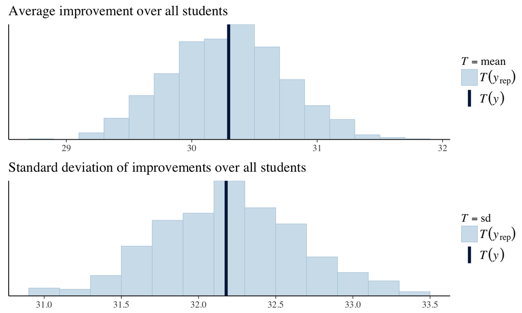

## Visualizing model fit (w. uncertainty)

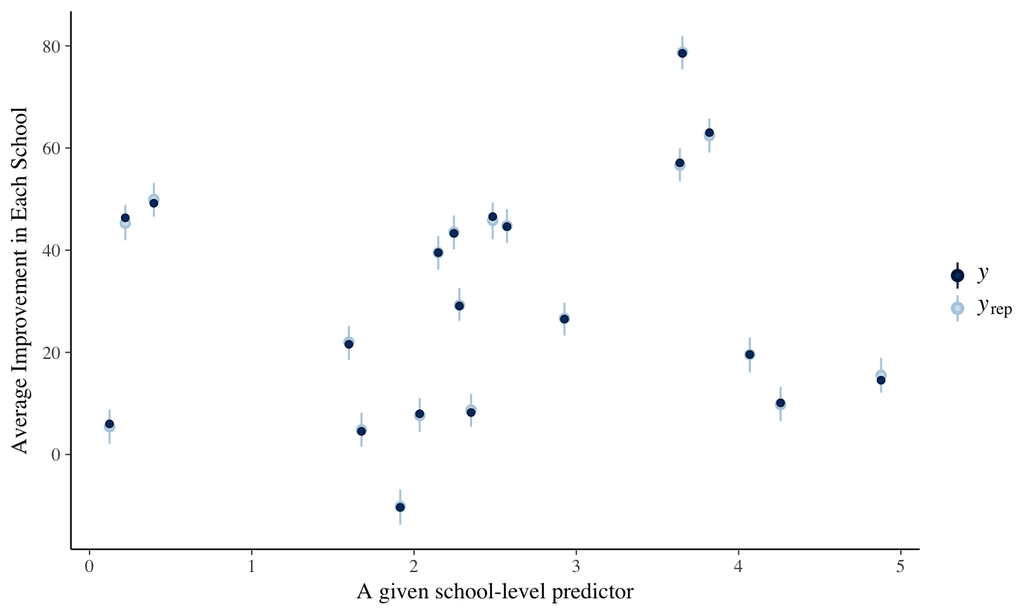

## Visualizing model fit (w. uncertainty)

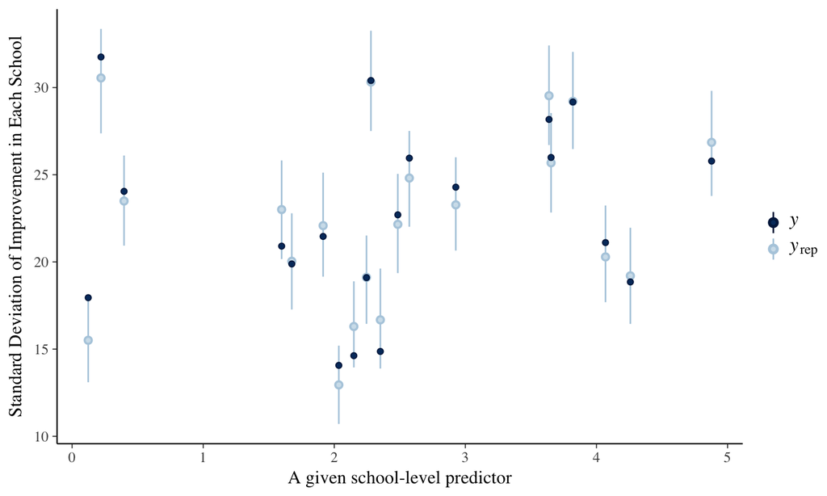

## Visualizing model fit

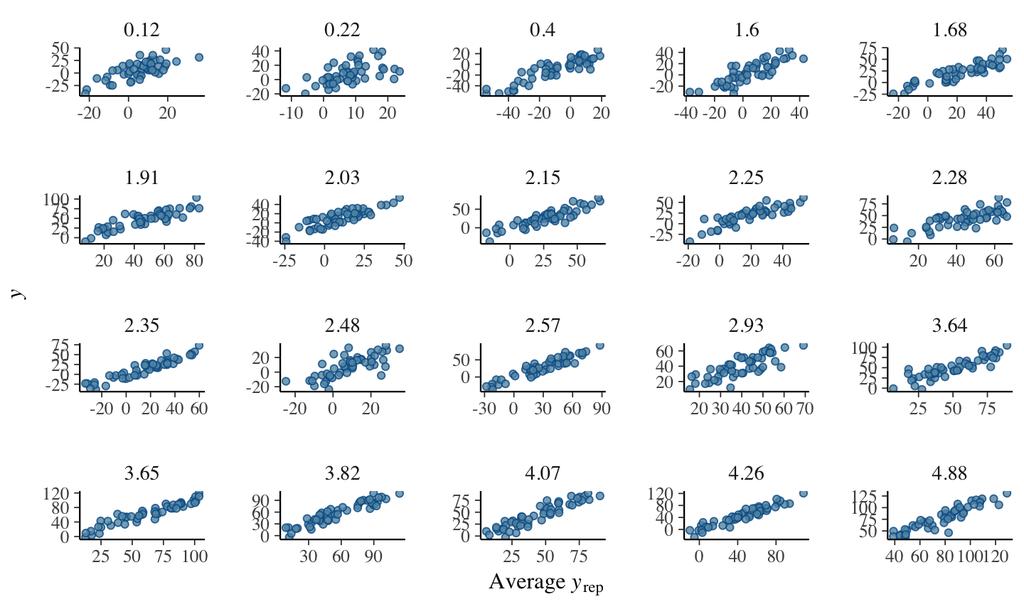

Shiny applications not supported in static R Markdown documents